# Exam1_Frost

2026-03-10

Julia Frost FeederWatch Data Analysis Graphing Bird Population Patterns

```r
library(tidyverse)
library(arrow)
```

```r
library(ggplot2)
```

Downloading data

```r
birddataset <- list(
  open_dataset("~/../shared/feederwatch/PFW_all_1988_1995_May2024_Public.csv", format = "csv"),
  open_dataset("~/../shared/feederwatch/PFW_all_1996_2000_May2024_Public.csv", format = "csv"),
  open_dataset("~/../shared/feederwatch/PFW_all_2001_2005_May2024_Public.csv", format = "csv"),
  open_dataset("~/../shared/feederwatch/PFW_all_2006_2010_May2024_Public.csv", format = "csv"),
  open_dataset("~/../shared/feederwatch/PFW_all_2011_2015_May2024_Public.csv", format = "csv"),
  open_dataset("~/../shared/feederwatch/PFW_all_2016_2020_May2024_Public.csv", format = "csv"),
  open_dataset("~/../shared/feederwatch/PFW_all_2021_2024_May2024_Public.csv", format = "csv")
)

#View
names(birddataset[[1]])
```

```
##  [1] "LOC_ID"             "LATITUDE"           "LONGITUDE"
##  [4] "SUBNATIONAL1_CODE"  "ENTRY_TECHNIQUE"    "SUB_ID"
##  [7] "OBS_ID"             "Month"              "Day"
## [10] "Year"               "PROJ_PERIOD_ID"     "SPECIES_CODE"
## [13] "alt_full_spp_code"  "HOW_MANY"           "PLUS_CODE"
## [16] "VALID"              "REVIEWED"           "DAY1_AM"
## [19] "DAY1_PM"            "DAY2_AM"            "DAY2_PM"
## [22] "EFFORT_HRS_ATLEAST" "SNOW_DEP_ATLEAST"   "Data_Entry_Method"
```

```r
birddataset[[1]] |>
  head(10) |>
  collect()
```

```
## # A tibble: 10 × 24
##    LOC_ID  LATITUDE LONGITUDE SUBNATIONAL1_CODE ENTRY_TECHNIQUE SUB_ID  OBS_ID
##    <chr>      <dbl>     <dbl> <chr>             <chr>           <chr>   <chr>
##  1 L103924     42.6     -83.2 US-MI             PointMaker1.0_2 S119768 OBS6669…
##  2 L103924     42.6     -83.2 US-MI             PointMaker1.0_2 S119768 OBS6669…
##  3 L103924     42.6     -83.2 US-MI             PointMaker1.0_2 S119768 OBS7763…
##  4 L103924     42.6     -83.2 US-MI             PointMaker1.0_2 S119768 OBS5875…
##  5 L103924     42.6     -83.2 US-MI             PointMaker1.0_2 S119768 OBS5875…
##  6 L103924     42.6     -83.2 US-MI             PointMaker1.0_2 S119768 OBS4316…
##  7 L103924     42.6     -83.2 US-MI             PointMaker1.0_2 S119768 OBS4316…
##  8 L103924     42.6     -83.2 US-MI             PointMaker1.0_2 S119768 OBS8505…
##  9 L103924     42.6     -83.2 US-MI             PointMaker1.0_2 S119768 OBS4824…
## 10 L103924     42.6     -83.2 US-MI             PointMaker1.0_2 S119768 OBS4824…
## # ℹ 17 more variables: Month <int>, Day <int>, Year <int>,
## #   PROJ_PERIOD_ID <chr>, SPECIES_CODE <chr>, alt_full_spp_code <chr>,
## #   HOW_MANY <int>, PLUS_CODE <int>, VALID <int>, REVIEWED <int>,
## #   DAY1_AM <int>, DAY1_PM <int>, DAY2_AM <int>, DAY2_PM <int>,
## #   EFFORT_HRS_ATLEAST <dbl>, SNOW_DEP_ATLEAST <dbl>, Data_Entry_Method <???>
```

Question 1: What are the Top 10 most common bird sightings in New England? The top 10 most commonly observed bird species in New England were identified using FeederWatch data from 1988 to 2024. Total observations were summed per species across all six New England states and visualized in a bar chart to highlight the most frequently recorded birds at feeders.

```r
#New England state codes
new_england_states <- c("US-CT", "US-MA", "US-ME", "US-NH", "US-RI", "US-VT")

#Filter New England and observations per species
top10_birds <- map_dfr(birddataset, function(ds) {
  ds |>
    filter(SUBNATIONAL1_CODE %in% new_england_states,
           Year <= 2024) |>
    select(SPECIES_CODE, HOW_MANY) |>
    collect()
}) |>
  group_by(SPECIES_CODE) |>
  summarise(total_observations = sum(HOW_MANY, na.rm = TRUE), .groups = "drop") |>
  arrange(desc(total_observations)) |>
  slice_head(n = 10)

#Print top 10 most common birds
print(top10_birds)
```

```
## # A tibble: 10 × 2
##    SPECIES_CODE total_observations
##    <chr>                     <int>
##  1 moudov                  2082764
##  2 amegfi                  2055870
##  3 daejun                  2006039
##  4 bkcchi                  1463742
##  5 blujay                  1197203
##  6 houspa                  1176389
##  7 houfin                   788728
##  8 tuftit                   767732
##  9 eursta                   752994
## 10 norcar                   711547
```

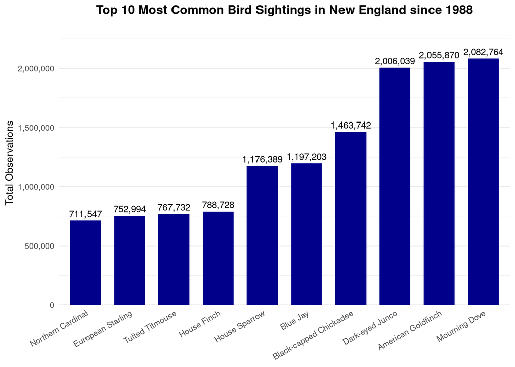

```r
#Species names
species_names <- c(
  "amegfi" = "American Goldfinch",
  "blujay" = "Blue Jay",
  "bkcchi" = "Black-capped Chickadee",
  "daejun" = "Dark-eyed Junco",
  "eursta" = "European Starling",
  "houfin" = "House Finch",
  "houspa" = "House Sparrow",
  "moudov" = "Mourning Dove",
  "norcar" = "Northern Cardinal",
  "tuftit" = "Tufted Titmouse"
)

#Add common names to the dataframe
top10_birds <- top10_birds |>
  mutate(common_name = recode(SPECIES_CODE, !!!species_names, .default = SPECIES_CODE))

#Plot
ggplot(top10_birds, aes(x = reorder(common_name, total_observations), y = total_observations)) +
  geom_col(fill = "darkblue", width = 0.7) +
  geom_text(aes(label = scales::comma(total_observations)),
            vjust = -0.5, size = 3.2, color = "black") +
  scale_y_continuous(labels = scales::comma, expand = expansion(mult = c(0, 0.15))) +
  labs(
    title = "Top 10 Most Common Bird Sightings in New England since 1988",
    x = NULL,
    y = "Total Observations"
  ) +
  theme_minimal(base_size = 10) +
  theme(
    plot.title = element_text(face = "bold", hjust = 0.5),
    panel.grid.major.x = element_blank(),
    axis.text.x = element_text(angle = 30, hjust = 1)
  )
```

Question 2: How have American Robin winter observations in New England since 1988? The linear regression revealed a statistically significant increase in American Robin winter observations over time p-value of 1.50e-10. This suggests that winter is a strong predictor of robin sightings in New England, indicating a clear upward trend in robin presence during winter months with robin observations increasing since 1989.

```r
#New England state codes
new_england_states <- c("US-CT", "US-MA", "US-ME", "US-NH", "US-RI", "US-VT")

robin_winter <- map_dfr(birddataset, function(ds) {
  ds |>
    filter(SUBNATIONAL1_CODE %in% new_england_states,
           SPECIES_CODE == "amerob",
           Month %in% c(12, 1, 2),
           Year <= 2023) |>
    select(Year, Month, HOW_MANY) |>
    collect()
}) |>
  #Assign winter season year
  mutate(
    winter_year = if_else(Month == 12, Year + 1, Year)
  ) |>
  group_by(winter_year) |>
  summarise(total_observations = sum(HOW_MANY, na.rm = TRUE), .groups = "drop") |>
  filter(winter_year >= 1989, winter_year <= 2023) |>
  arrange(winter_year)

#Print
print(robin_winter)
```

```
## # A tibble: 35 × 2
##    winter_year total_observations
##          <dbl>              <int>
##  1        1989                110
##  2        1990                 60
##  3        1991                102
##  4        1992                294
##  5        1993                273
##  6        1994                203
##  7        1995                947
##  8        1996                259
##  9        1997                726
## 10        1998                843
## # ℹ 25 more rows
```

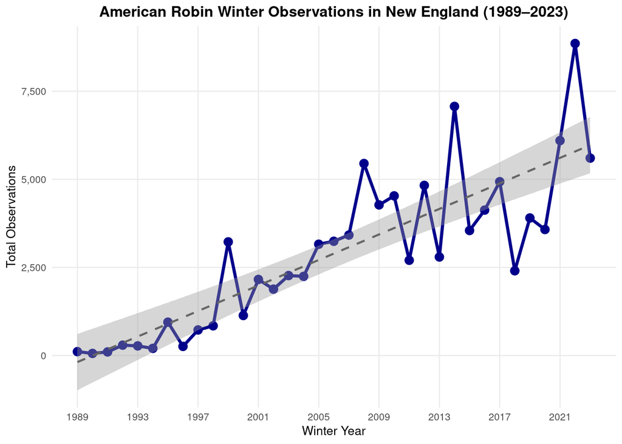

```r
#Line graph
ggplot(robin_winter, aes(x = winter_year, y = total_observations)) +
  geom_line(color = "darkblue", linewidth = 1.2) +
  geom_point(color = "darkblue", size = 3) +
  geom_smooth(method = "lm", se = TRUE, color = "gray40", linetype = "dashed", linewidth = 0.8) +
  scale_x_continuous(breaks = seq(1989, 2023, by = 4)) +
  scale_y_continuous(labels = scales::comma) +
  labs(
    title = "American Robin Winter Observations in New England (1989–2023)",
    x = "Winter Year",
    y = "Total Observations"
  ) +
  theme_minimal(base_size = 10) +
  theme(
    plot.title = element_text(face = "bold", hjust = 0.5),
    panel.grid.minor = element_blank()
  )
```

```r
#Test if Robin observations have increased over time
lm_model <- lm(total_observations ~ winter_year, data = robin_winter)

#Significances results
summary(lm_model)
```

```
##
## Call:
## lm(formula = total_observations ~ winter_year, data = robin_winter)
##
## Residuals:
##      Min       1Q   Median       3Q      Max
## -2660.71  -589.38   -74.66   397.74  3063.99
##
## Coefficients:
##               Estimate Std. Error t value Pr(>|t|)
## (Intercept) -360345.48   39787.41  -9.057 1.82e-10 ***
## winter_year     181.08      19.83   9.130 1.50e-10 ***
## ---
## Signif. codes:  0 '***' 0.001 '**' 0.01 '*' 0.05 '.' 0.1 ' ' 1
##
## Residual standard error: 1185 on 33 degrees of freedom
## Multiple R-squared:  0.7164, Adjusted R-squared:  0.7078
## F-statistic: 83.35 on 1 and 33 DF,  p-value: 1.505e-10
```

Question 3: Which state in the northeast has the most bird observations? Total bird observations were compared across six New England states using FeederWatch data. Observations were gathered per state and visualized in a bar chart to identify which state recorded the highest number of bird sightings.

```r
#Which state in the northeast has the most bird observations

northeast_states <- c("US-CT", "US-MA", "US-VT", "US-NH", "US-ME", "US-RI")

# Pull and summarise observations by state
northeast_birds <- map_dfr(birddataset, ~ .x |>
                             filter(SUBNATIONAL1_CODE %in% northeast_states) |>
                             select(SUBNATIONAL1_CODE, HOW_MANY) |>
                             collect()
) |>
  filter(!is.na(HOW_MANY)) |>
  group_by(SUBNATIONAL1_CODE) |>
  summarise(total_observed = sum(HOW_MANY, na.rm = TRUE), .groups = "drop") |>
  mutate(
    state = recode(SUBNATIONAL1_CODE,
                   "US-CT" = "Connecticut",
                   "US-MA" = "Massachusetts",
                   "US-VT" = "Vermont",
                   "US-NH" = "New Hampshire",
                   "US-ME" = "Maine",
                   "US-RI" = "Rhode Island"
    )
  ) |>
  arrange(desc(total_observed))

#Check output
print(northeast_birds)
```

```
## # A tibble: 6 × 3
##   SUBNATIONAL1_CODE total_observed state
##   <chr>                      <int> <chr>
## 1 US-MA                    6388072 Massachusetts
## 2 US-CT                    4576273 Connecticut
## 3 US-ME                    3112747 Maine
## 4 US-NH                    2232759 New Hampshire
## 5 US-VT                    1872346 Vermont
## 6 US-RI                     627757 Rhode Island
```

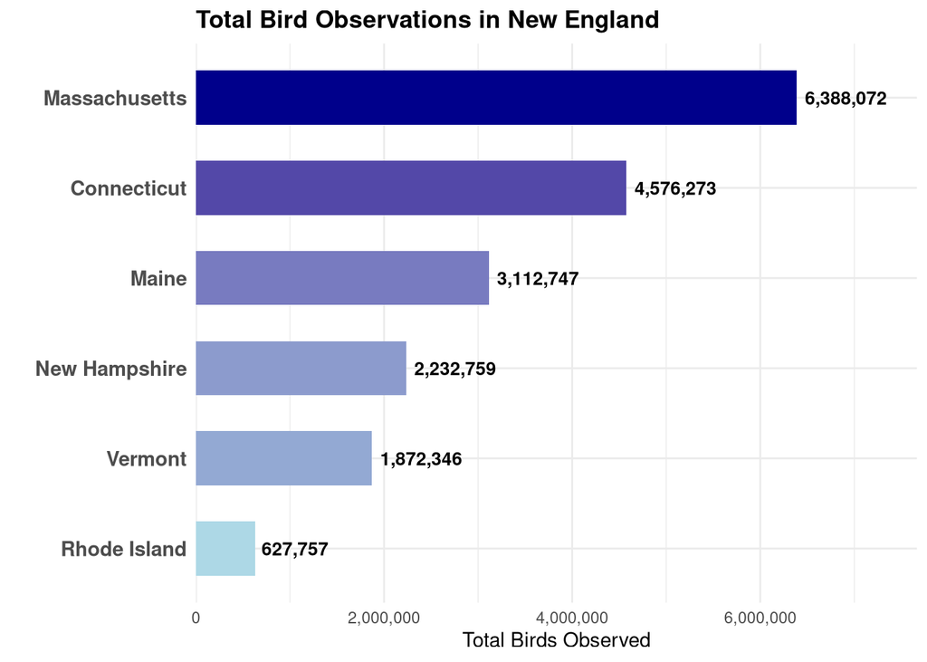

```r
ggplot(northeast_birds, aes(x = reorder(state, total_observed),
                            y = total_observed, fill = total_observed)) +
  geom_col(width = 0.6) +
  geom_text(aes(label = scales::comma(total_observed)),    # ← formatted numbers on bars
            hjust = -0.1, size = 3.5, fontface = "bold") +
  scale_fill_gradient(low = "lightblue", high = "darkblue") +
  scale_y_continuous(
    labels = scales::comma,
    expand = expansion(mult = c(0, 0.2))
  ) +
  coord_flip() +
  labs(
    title = "Total Bird Observations in New England",
    x = "",
    y = "Total Birds Observed"
  ) +
  theme_minimal() +
  theme(
    legend.position = "none",
    axis.text.y = element_text(size = 11, face = "bold"),
    plot.title = element_text(face = "bold")
  )
```

Question 4: Have total bird observations increased in New England since 1988? Total bird observations in New England were grouped into 4-year periods from 1988 to 2023. A linear regression was applied to test whether total observations significantly changed over time. The p-value is 8.522e-05 which means the results are significant and bird observations have increased in New England since 1988.

```r
#New England states from Feederwatch
new_england_states <- c("US-CT", "US-MA", "US-ME", "US-NH", "US-RI", "US-VT")

#4 year period grouped together
new_england_obs <- map_dfr(birddataset, function(ds) {
  ds |>
    filter(SUBNATIONAL1_CODE %in% new_england_states,
           Year <= 2023) |>
    select(Year, HOW_MANY) |>
    collect()
}) |>
  mutate(
    period_start = floor((Year - 1988) / 4) * 4 + 1988,
    period_label = paste0(period_start, "–", period_start + 3)
  ) |>
  group_by(period_start, period_label) |>
  summarise(total_observations = sum(HOW_MANY, na.rm = TRUE), .groups = "drop") |>
  arrange(period_start)

# View summary
print(new_england_obs)
```

```
## # A tibble: 9 × 3
##   period_start period_label total_observations
##          <dbl> <chr>                     <int>
## 1         1988 1988–1991                798917
## 2         1992 1992–1995               1323921
## 3         1996 1996–1999               1240091
## 4         2000 2000–2003               1861757
## 5         2004 2004–2007               1951292
## 6         2008 2008–2011               2050829
## 7         2012 2012–2015               2350008
## 8         2016 2016–2019               2753966
## 9         2020 2020–2023               3829485
```

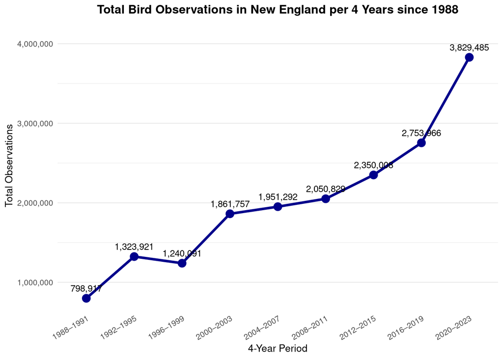

```r
# Line graph
ggplot(new_england_obs, aes(x = reorder(period_label, period_start), y = total_observations, group = 1)) +
  geom_line(color = "darkblue", linewidth = 1.2) +
  geom_point(color = "darkblue", size = 3.5) +
  geom_text(aes(label = scales::comma(total_observations)),
            vjust = -1, size = 3.2, color = "black") +
  scale_y_continuous(labels = scales::comma, expand = expansion(mult = c(0.05, 0.15))) +
  labs(
    title = "Total Bird Observations in New England per 4 Years since 1988",
    x = "4-Year Period",
    y = "Total Observations"
  ) +
  theme_minimal(base_size = 10) +
  theme(
    plot.title = element_text(face = "bold", hjust = 0.5),
    axis.text.x = element_text(angle = 30, hjust = 1),
    panel.grid.major.x = element_blank()
  )
```

```r
# Test if bird observations have increased over time
lm_model <- lm(total_observations ~ period_start, data = new_england_obs)

# Significance results
summary(lm_model)
```

```
##
## Call:
## lm(formula = total_observations ~ period_start, data = new_england_obs)
##
## Residuals:
##     Min      1Q  Median      3Q     Max
## -295176 -204907  -66515  157638  556923
##
## Coefficients:
##                Estimate Std. Error t value Pr(>|t|)
## (Intercept)  -155140156   19439499  -7.981 9.26e-05 ***
## period_start      78422       9700   8.085 8.52e-05 ***
## ---
## Signif. codes:  0 '***' 0.001 '**' 0.01 '*' 0.05 '.' 0.1 ' ' 1
##
## Residual standard error: 300600 on 7 degrees of freedom
## Multiple R-squared:  0.9033, Adjusted R-squared:  0.8894
## F-statistic: 65.36 on 1 and 7 DF,  p-value: 8.522e-05
```

AI Statement: Claude Sonnet 4.6 was used to improve this code by making sure it would be able to run on the online server and not load too much data. Claude also helped with the appearance of graphs, wrote code for “theme_minimal” and explained how to change text size